# Morning Recap

December 14, 2015

## Morning Topics

Any Questions?

- Introductions
- Getting Started
- Vectors
- Data
- Loss Distributions
- Visualization

## Problem 1

Use the lognormal distribution.. Generate a large random sample. Do some of the following

- Create a vector of summary statistics.
- Create a histogram log of the distribution to see if it looks normal.
- Use `qnorm` as another check to see if the log is a normal distribution.

## Problem 2

Using the `Teams` datset in the `Lahman` package, choose a `teamID`.

- Create a data frame with `W`, `L`, `attendance` for years 1980 - 2014 for your selected team.
- Create a scatterplot to explore the relationship between wins and attendance.
- Determine the National League team that had the most wins in the 1920's.

## Problem 3

Using the iris dataset,

- Create different boxplots for the Sepal Length by species and display them in the same plot.
- Modify the plot by adding a descriptive title
- Plot Petal Width against Petal Length with points colored according to Species.
- Add a legend.

## Problem 1 Solution

The lognormal distribution has parameters `meanlog` and `sdlog`. This means that if X is lognormal then logX is normal with mean `meanlog` and standard deviation `sdlog`.

```r
  num<-10000;  ml<-5;  sdl<-2
  x1<-rlnorm(num,meanlog=ml,sdlog=sdl)
  q1<-quantile(x1,probs=seq(from=.1,to=.9,by=.1))
  mySummary<-c(min(x1),max(x1),mean(x1),sd(x1),q1)
  names(mySummary)[1:4]<-c("Min","Max","Mean","SD")
  mySummary
```

```
##          Min          Max         Mean           SD          10%
## 1.013653e-01 4.439816e+05 1.090552e+03 7.030215e+03 1.230013e+01
##          20%          30%          40%          50%          60%
## 2.891790e+01 5.422483e+01 9.459349e+01 1.533342e+02 2.448417e+02
##          70%          80%          90%
## 4.274052e+02 8.201714e+02 1.938964e+03
```

```r
y1<-log(x1)
(m1<-mean(y1))
```

```
## [1] 5.02977
```

```r
(s1<-sd(y1))
```

```
## [1] 1.978059
```

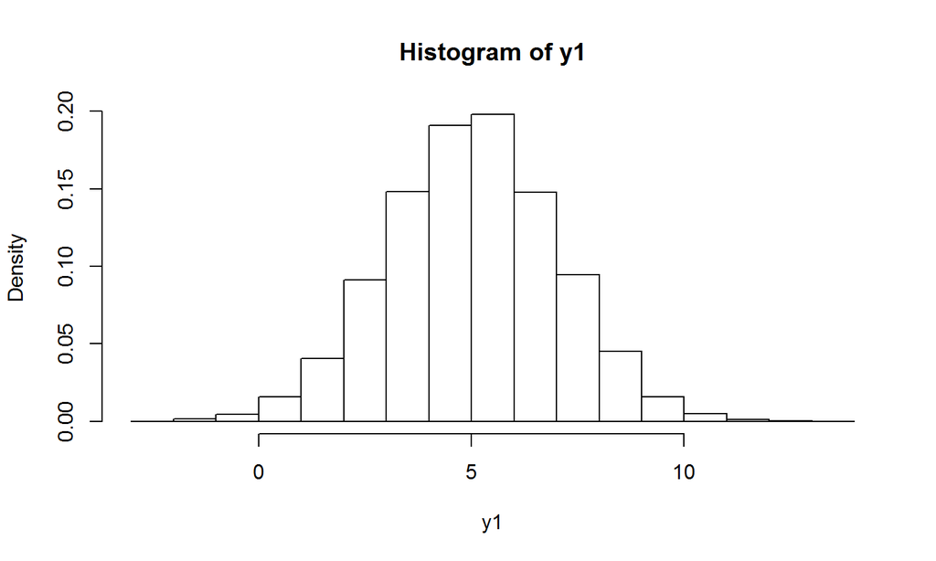

```r
hist(y1,freq=FALSE)
```

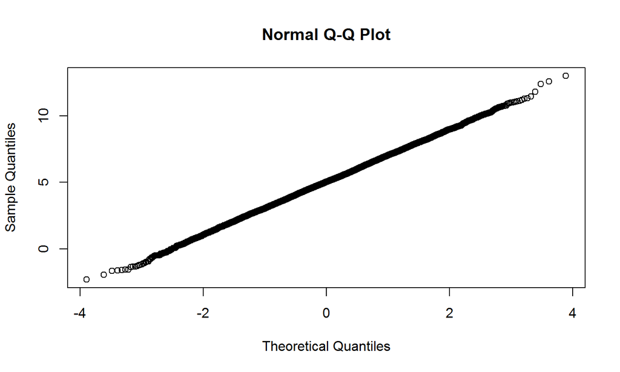

```r
qqnorm(y1)
```

## Problem 2 Solution

```r
  suppressWarnings(library(Lahman)); data(Teams)
```

Filter the years and select the columns `yearID`, `teamID`, `W`, and `attendance`.

```r
  data1<-Teams[Teams$yearID>1979,c("yearID","teamID","W","attendance")]
  head(data1)
```

```
##      yearID teamID   W attendance
## 1788   1980    ATL  81    1048411
## 1789   1980    BAL 100    1797438
## 1790   1980    BOS  83    1956092
## 1791   1980    CAL  65    2297327
## 1792   1980    CHA  70    1200365
## 1793   1980    CHN  64    1206776
```

Let's choose Atlanta.

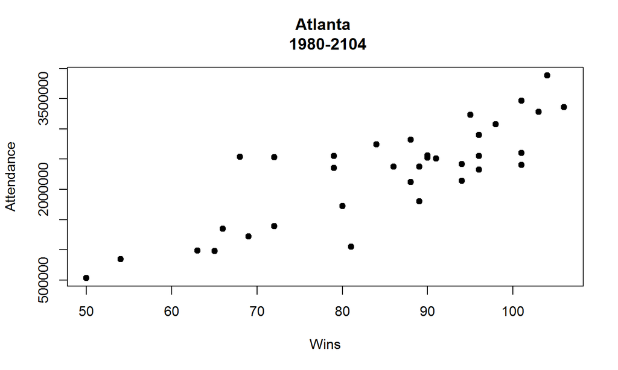

```r
  atl<-data1[data1$teamID=="ATL",]
  plot(x=atl$W,y=atl$attendance,pch=19,xlab="Wins",ylab="Attendance")
  title(main="Atlanta \n 1980-2104")
```

```r
data1920<-Teams[Teams$yearID > 1919 & Teams$yearID<1930
                & Teams$lgID=="NL",c("yearID","teamID","W")]
head(data1920)
```

```
##     yearID teamID  W
## 705   1920    BRO 93
## 706   1920    BSN 62
## 708   1920    CHN 75
## 709   1920    CIN 82
## 712   1920    NY1 86
## 715   1920    PHI 62
```

```r
  totalWins<-aggregate(W~teamID,data=data1920,FUN=sum)
  dim(totalWins)
```

```
## [1] 8 2
```

```r
  totalWins
```

```
##   teamID   W
## 1    BRO 765
## 2    BSN 603
## 3    CHN 807
## 4    CIN 798
## 5    NY1 890
## 6    PHI 566
## 7    PIT 877
## 8    SLN 822
```

## Problem 3 Solution

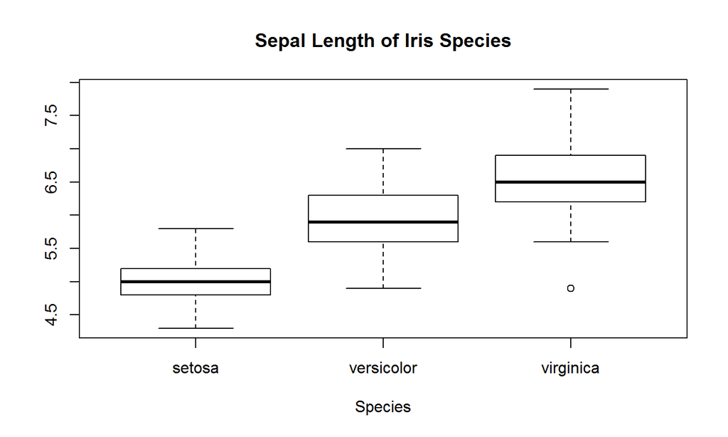

```r
data(iris)
boxplot(Sepal.Length~Species,data=iris,xlab="Species")
title(main="Sepal Length of Iris Species")
```

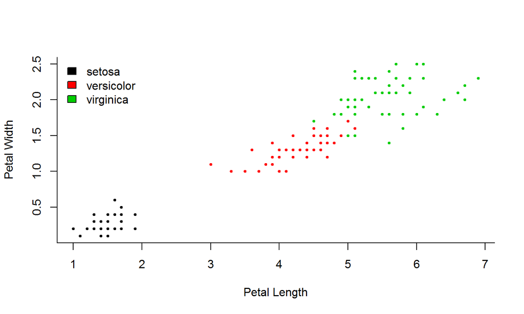

```r
plot(x=iris$Petal.Length,y=iris$Petal.Width,pch=19,cex=.5,
     bty="l",xlab="Petal Length",ylab="Petal Width",
     col=as.numeric(iris$Species))
legend("topleft",fill=palette()[1:3],
       legend=levels(iris$Species),bty="n")
```